# Introductions to the F1

11/1/2020

## The Suzuka Circuit

In 1962, Japan built its own international racing course, the Suzuka circuit. Since then, the Suzuka Circuit has been hosting numerous racing events like the Formula One Japanese Grand Prix. A feature of the Suzuka Circuit is its distinctive figure-8 layout, which is quite rare globally, and laid out with plenty of sharp curves<sup>[1]</sup>.

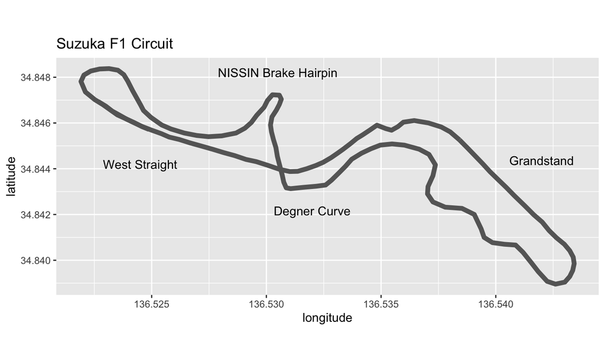

## Elevation changes

The elevation change in the Suzuka circuit is 40.4m, which plays a big part of fun for Suzuka drivers.<sup>[2]</sup> And, it has considerably more ups and downs than most circuits. Drivers are dropping downhill all the way in front of the grandstand, which can not be recognized from a 2D chart in the previous page. Now, we try to visualize with a 3D interactive plot by Plotly.

[interactive chart not shown]

## Refeferences

[1] ANA, “Suzuka Circuit”, https://www.ana-cooljapan.com/destinations/mie/suzukacircuit  
[2] Formula One World Championship Limited, “Highs and lows - which F1 track has the most elevation changes?”, [https://w"ww.formula1.com/en/latest/features/2016/10/highs-and-lows—which-f1-track-has-the-most-elevation-changes-.html](https://w%22ww.formula1.com/en/latest/features/2016/10/highs-and-lows---which-f1-track-has-the-most-elevation-changes-.html)

Remark: This package was created for an assignment of “Developing Data PRoducts”, Coursera, and will be removed immediately after a peer review.